# Cyclistic Case Study

Suzana Alípio

2024-12-20

# Introduction

The Cyclistic Bike-Share Case Study is a capstone project for the Google Data Analytics Certificate. This study follows the six-step data analysis process: Ask, Prepare, Process, Analyze, Share, and Act, focusing on a fictional bike-sharing company in Chicago, Cyclistic, which launched in 2016. The program currently operates 5,800 bicycles and 600 stations, offering inclusive options such as reclining bikes, hand tricycles, and cargo bikes. Cyclistic’s financial analysts concluded that annual members are more profitable than casual riders. The marketing team, led by Lily Moreno, aims to increase the number of annual memberships by converting casual riders into long-term members. The key goal of this study is to analyze historical usage data to understand how annual members and casual riders use Cyclistic bikes differently. These insights will inform a targeted marketing strategy to drive growth and long-term profitability.

# Ask Phase

### Clear Statement of the Business Task

Cyclistic seeks to understand the differences in usage patterns between annual members and casual riders. This analysis aims to identify opportunities to increase annual membership through data-driven targeted strategies.

### Key Questions

1. How do annual members and casual riders use Cyclistic bikes differently?
2. What motivates casual riders to purchase annual memberships?
3. How can Cyclistic leverage digital media to convert casual riders into members?

### Key Stakeholders

- Lily Moreno, marketing director, responsible for promotional campaigns.
- Cyclistic Marketing Analytics Team, tasked with data collection, analysis, and reporting.
- Cyclistic Executives, who will make decisions based on the insights presented.

### Impact on Decision Makers

The insights generated in this analysis will help to:

- Inform strategic decisions about marketing campaigns.
- Prioritize resources for stations and times most used by casual riders.
- Increase profitability by maximizing the conversion of casual riders into members.

# Prepare Phase

### Data Sources

The data used in this study consists of 12 months of historical trip records from Cyclistic, spanning from November 2023 to October 2024. These datasets were downloaded from Cyclistic’s official website and provided under the public license at [Cyclistic Data License Agreement](https://divvybikes.com/data-license-agreement).

The datasets include detailed trip information, such as user type (casual or member), bike type, trip times, and start and end locations. This structure enables a comprehensive analysis of usage patterns.

### Data Organization

Due to the large volume of records, the data is organized into 12 CSV files (one per month) and stored in Google Cloud Storage (GCS). These files were processed and analyzed in BigQuery using SQL, which was most suitable for handling millions of records.

Each file contains 13 columns with the same format, as outlined below:

- ride_id: Unique identifier for each trip.
- rideable_type: Type of bike (classic, electric, or docked).
- started_at and ended_at: Start and end date and time of the trip.
- start_station_name and end_station_name: Names of the start and end stations.
- start_station_id and end_station_id: Identifiers of the start and end stations.
- start_lat, start_lng, end_lat, end_lng: Geographic coordinates of the stations.
- member_casual: User type (annual member or casual rider).

### Data Reliability and Credibility

The data adheres to ROCCC (Reliable, Original, Comprehensive, Current, Cited) criteria:

- Reliable: Provided by Cyclistic through an official source.
- Original: Collected directly by Cyclistic’s operational systems.
- Comprehensive: Includes detailed information on millions of trips.
- Current: Covers a recent and relevant period for analysis.
- Cited: Publicly available data under a licensed agreement.

### Privacy and Security

The datasets respect user privacy and do not include personally identifiable information such as names or credit card numbers. This ensures anonymity and compliance with privacy regulations.

### Data Preparation

During this phase, the strategy adopted was to list identified issues before cleaning or manipulation to ensure all problems were systematically addressed in the Process phase. The checks performed include:

1. Structural Validation:
- Confirmed that all tables had the same columns and formats.
- Identified missing or inconsistent values.
2. Problem Analysis:
- Records with null values in essential columns.
- Cases where the start time (started_at) did not precede the end time (ended_at).
- Potential duplicate records.
3. BigQuery Utilization:
- Checks and problem listings were conducted using SQL queries in BigQuery.

### Relevance to the Business Question

The prepared data provides a robust foundation to answer the primary business question: How do annual members and casual riders use Cyclistic bikes differently? Additionally, it enables detailed analysis of routes, usage patterns, and preferred bike types.

# Process Phase

### Description of Data Cleaning and Manipulation Process

During this phase, we carried out data cleaning, manipulation, and essential transformations to prepare the data for analysis without performing any interpretation or analysis. The adopted strategy included:

1. Verifying inconsistencies and issues in the data.
2. Applying transformations to address the identified problems.
3. Creating a clean and consolidated table in BigQuery using SQL.
4. Adding the column ride_length_minutes to calculate the duration of trips in minutes.

### Process Steps

#### 1. Tools Used

- Google Cloud Storage (GCS): To store the CSV files due to the large volume of data.
- BigQuery: This is for data processing and cleaning, given its ability to handle millions of records efficiently.
- SQL: To identify, list, and address issues in the data, as well as to add relevant transformations.

#### 2. Cleaning Steps

**a. Creation of a Consolidated Table**

- We consolidated the 12 CSV files, spanning November 2023 to October 2024, into a single table named my_cyclistic_csv_combined, using the following query:

```sql
CREATE TABLE `oval-airship-437710-u0.my_cyclistic_csv_data.my_cyclistic_csv_combined` AS
SELECT *
FROM (
    SELECT * FROM `oval-airship-437710-u0.my_cyclistic_csv_data.202311_cyclistic`
    UNION ALL
    -- other months follow the same pattern
    SELECT * FROM `oval-airship-437710-u0.my_cyclistic_csv_data.202410_cyclistic`
);
```

**b. Duplicate Check**

We identified 362,729 duplicate ride_id values using the following query:

```sql
SELECT
    ride_id,
    COUNT(ride_id) AS duplicate_count
FROM
    `oval-airship-437710-u0.my_cyclistic_csv_data.my_cyclistic_csv_combined`
GROUP BY
    ride_id
HAVING
    COUNT(ride_id) > 1
ORDER BY
    duplicate_count DESC;
```

**c. Error Identification**

1. Columns with Null Values: We checked for nulls in all relevant columns.
2. Records with ended_at Earlier than started_at:
- We found 322 records where ended_at was earlier than started_at:

```sql
SELECT
    ride_id, started_at, ended_at
FROM
    `oval-airship-437710-u0.my_cyclistic_csv_data.my_cyclistic_csv_combined`
WHERE
    ended_at < started_at;
```

**d. Applied Transformations**

We applied the following transformations:

1. Removal of Null Values: Ensured that no essential columns contained missing values.
2. Elimination of Duplicates: Used DISTINCT to remove duplicate rows.
3. Formatting Corrections:
- TRIM: Removed extra spaces.
- LOWER: Standardized text to lowercase for consistency.
4. ride_length Restriction:
- Only trips with a duration greater than zero and less than 24 hours were included.

Final Query to Create the Clean Table:

```sql
CREATE OR REPLACE TABLE `oval-airship-437710-u0.my_cyclistic_csv_data.my_cyclistic_csv_cleaned` AS
SELECT DISTINCT
    TRIM(ride_id) AS ride_id,
    TRIM(rideable_type) AS rideable_type,
    started_at,
    ended_at,
    TRIM(start_station_name) AS start_station_name,
    TRIM(start_station_id) AS start_station_id,
    TRIM(end_station_name) AS end_station_name,
    TRIM(end_station_id) AS end_station_id,
    start_lat,
    start_lng,
    end_lat,
    end_lng,
    LOWER(TRIM(member_casual)) AS member_casual
FROM
    `oval-airship-437710-u0.my_cyclistic_csv_data.my_cyclistic_csv_combined`
WHERE
    ride_id IS NOT NULL
    AND rideable_type IS NOT NULL
    AND started_at IS NOT NULL
    AND ended_at IS NOT NULL
    AND ended_at > started_at
    AND member_casual IS NOT NULL;
```

#### 3. Adding the ride_length_minutes Column

We calculated the duration of each trip in minutes and created the table my_cyclistic_csv_cleaned_with_length_minutes using the following query:

```sql
CREATE OR REPLACE TABLE `oval-airship-437710-u0.my_cyclistic_csv_data.my_cyclistic_csv_cleaned_with_length_minutes` AS
SELECT
    *,
    ROUND(TIMESTAMP_DIFF(ended_at, started_at, SECOND) / 60, 2) AS ride_length_minutes
FROM
    `oval-airship-437710-u0.my_cyclistic_csv_data.my_cyclistic_csv_cleaned`
WHERE
    started_at IS NOT NULL
    AND ended_at IS NOT NULL
    AND TIMESTAMP_DIFF(ended_at, started_at, SECOND) > 0
    AND TIMESTAMP_DIFF(ended_at, started_at, SECOND) <= 1440 * 60
    AND ROUND(TIMESTAMP_DIFF(ended_at, started_at, SECOND) / 60, 2) > 0
    AND ROUND(TIMESTAMP_DIFF(ended_at, started_at, SECOND) / 60, 2) <= 1440;
```

#### 4. Final Validation

After the transformations: - We verified the integrity of the data again:

```sql
SELECT COUNT(*) AS total_rides
FROM `oval-airship-437710-u0.my_cyclistic_csv_data.my_cyclistic_csv_cleaned_with_length_minutes`;
```

Final Result: 4,273,034 clean records, ready for analysis.

# Analyse Phase

Understanding Patterns Between Annual Members and Casual Users To better understand Cyclistic bike usage patterns, we identified three key variables that highlight significant differences between annual members and casual users:

1. Total Trips Taken
2. Types of Bikes Used
3. Trip Characteristics: Seasonality, Duration, Timing, and Location

#### *1. Total Trips Taken*

- **Volume**:
  - Annual members accounted for **64.12%** of trips, while casual users made up **35.88%**.
  - Members completed **2,739,930 trips**, while casual users recorded **1,533,104 trips**.
- **Day Type Trend**:
  - Members dominated weekday trips (**76.84%**), while casual users were more prominent on weekends (**38.07%**).
  - Annual members dominate weekday usage with **2,105,486 rides** compared to **949,451 rides** by casual users.
  - On weekends, casual users show relatively higher activity, recording **583,653 rides**, while members complete **634,444 rides**.

**Key Insight**:  
Annual members use bikes more consistently for regular commuting, while casual users show seasonal and leisure-oriented behavior.

#### *2. Types of Bikes Used*

- **Classic Bikes**:
  - Preferred by **66.07%** of members and **63.88%** of casual users.
- **Electric Bikes**:
  - Accounted for **33.12%** of member trips and **34.44%** of casual trips.
- **Electric Scooters**:
  - Had greater adoption among casual users (**1.68%**) compared to members (**0.81%**).

**Key Insight**:  
Classic bikes are the predominant choice for both groups. However, casual users show a higher interest in electric scooters and bikes, signaling potential growth in the leisure market.

#### *3. Trip Characteristics*

##### a. Seasonality and Months

- **Monthly Volume**:
  - Summer months (June to August) saw the highest trip volumes for both groups.
  - For members:
    - **September** had the highest trips (**320,850**), while **January** had the lowest (**96,066**).
  - For casual users:
    - **July** recorded the highest trips (**231,948**), while **January** had the fewest (**17,709**).
- **Seasonal Impact**:
  - During summer, members made **907,681 trips**, while casual users completed **668,817 trips**.
  - In winter, trips dropped significantly for both groups, with casual users recording only **92,553 trips**.

**Key Insight**:  
Seasonality significantly affects casual users, who peak in summer, while members exhibit more consistent usage, even during off-peak months.

##### b. Duration

- **Average Duration**:
  - Casual users: **23.93 minutes**.
  - Members: **12.43 minutes**.
- **Maximum Duration**:
  - Casual users: **1,439.83 minutes** (nearly 24 hours).
  - Members: **1,439.87 minutes**.

**Key Insight**:  
Casual users tend to take longer trips, often in leisure-oriented times and locations.

##### c. Timing

- **Hourly Trends**:
  - **Peak Hours for Annual Members**:
    - Members have the highest activity at **5 PM** (**300,057 rides**), aligning with evening commuting hours.
    - Other significant time slots include **4 PM** (**259,684 rides**) and **6 PM** (**223,601 rides**), reinforcing their usage for regular work-related travel.
  - **Peak Hours for Casual Users**:
    - Casual users are most active at **5 PM** (**148,220 rides**) and **4 PM** (**140,345 rides**), overlapping with members but likely tied to leisure rides during afternoon hours.
    - Additional notable times for casual users include **3 PM** (**123,836 rides**) and **6 PM** (**122,165 rides**).
  - **Key Insight**:  
    Members maintain consistent ride activity throughout the day, particularly during typical commuting hours (**8 AM, 12 PM, and 5 PM**).  
    Casual users show a preference for mid-afternoon and early evening rides, with relatively low activity during early morning and late-night hours. Ride activity sharply decreases after **9 PM** for both user types, reflecting limited bike usage during late-night hours.
- **Weekly Trends**:
  - Members had the highest usage during **weekdays**, particularly **Wednesdays** (**463,987 trips**).
  - Casual users were more active on **weekends**, especially **Saturdays** (**319,234 trips**).
- **Key Insight**:  
  Members’ structured weekday usage contrasts with casual users’ weekend leisure patterns.

##### d. Location

# Share Phase

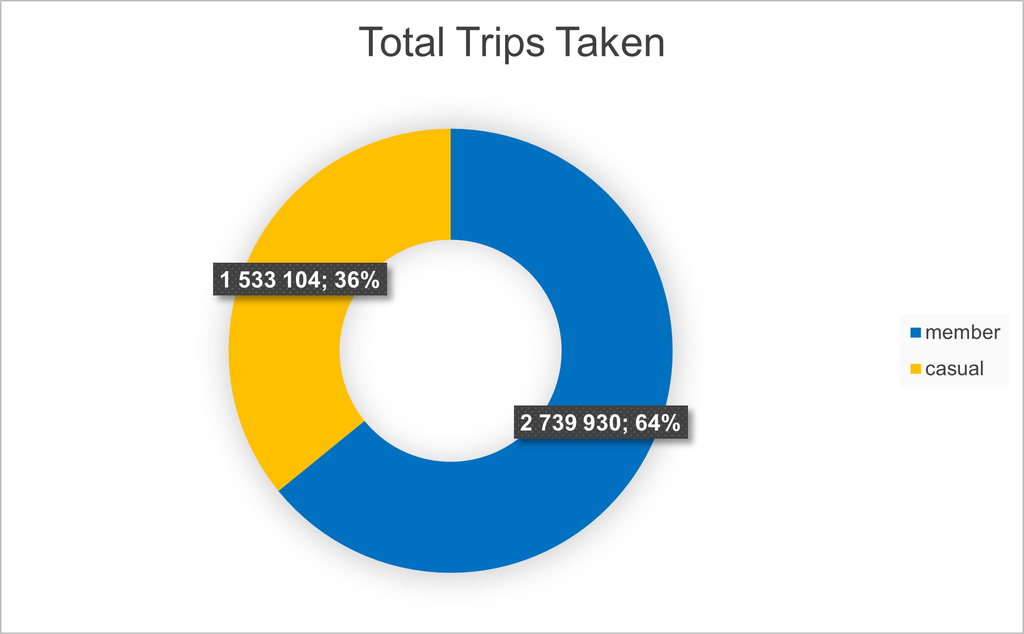

Annual members significantly dominate ride usage, nearly doubling the activity of casual riders. This highlights the stable and recurring use of bikes by members, likely tied to commuting and regular transportation needs.

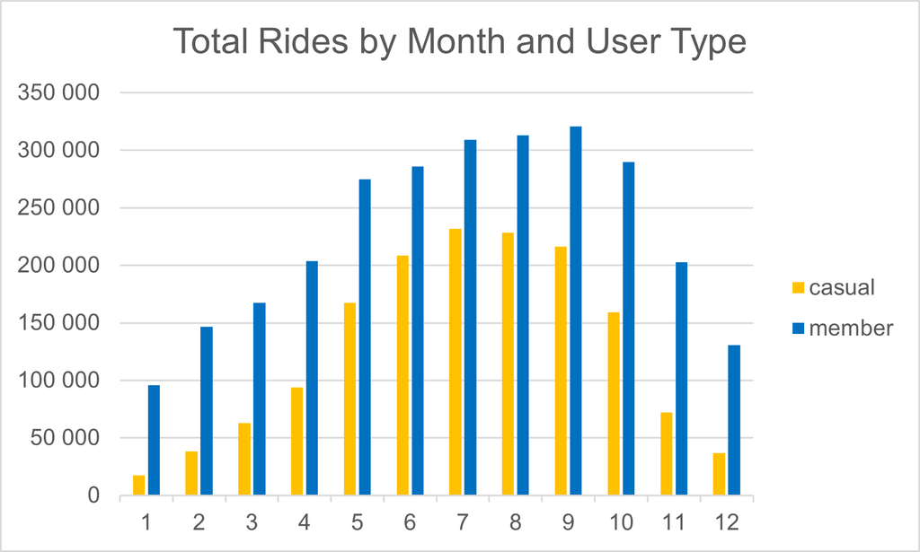

Annual members reached their peak number of trips in September, while casual users had their highest activity in July. Both groups saw increased ride activity during the summer months, likely due to cycling’s recreational appeal, which is better suited to warmer weather. This also explains the decline in trips during the colder winter months.

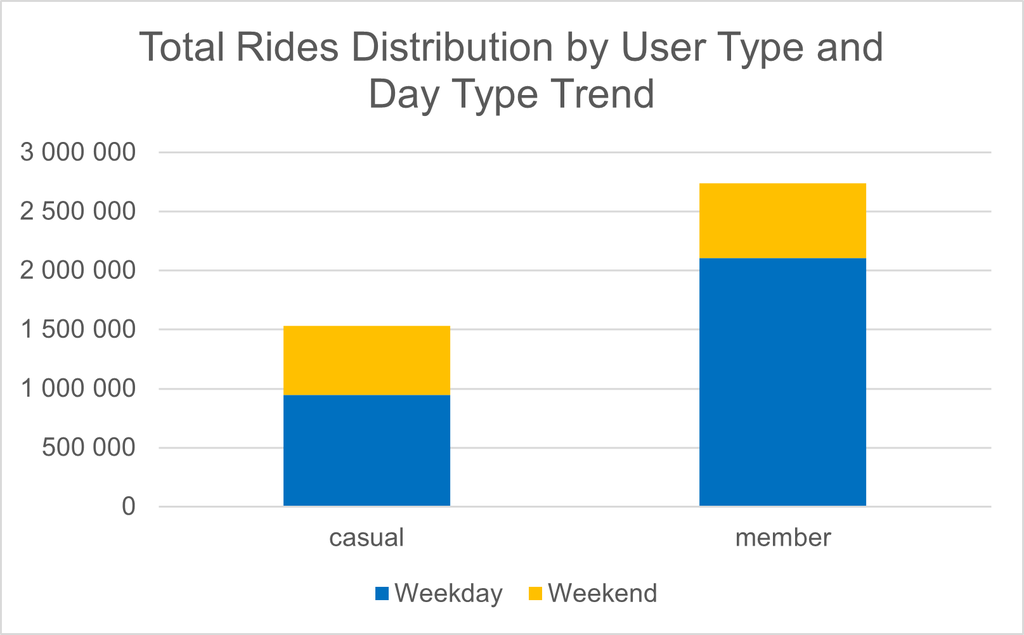

Highlights the differences in usage patterns between casual users and annual members. While annual members predominantly use the service on weekdays (76.84% of their trips), suggesting regular usage for commuting or daily activities, casual users also exhibit higher activity during weekdays (61.93%). However, casual users show a relatively higher proportion of weekend usage (38.07%), which may indicate a combination of leisure and commuting purposes. Overall, annual members completed significantly more total rides (2,739,930) compared to casual users (1,533,104).

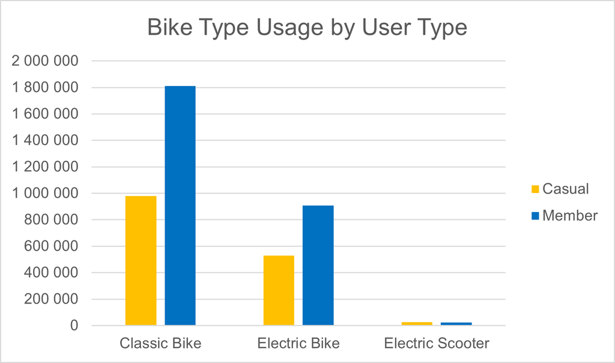

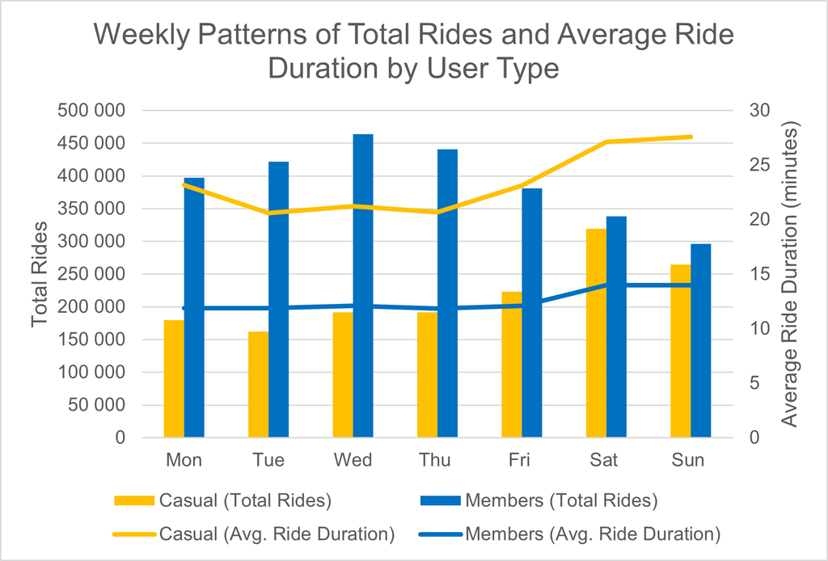

This visualization highlights the weekly patterns in bike usage among casual users and annual members. Casual users show a clear preference for weekends, with significantly higher average ride durations on Saturdays and Sundays compared to weekdays. In contrast, annual members demonstrate consistent usage throughout the week, with their total rides peaking mid-week. The data underscores the difference in usage behavior, with casual riders leaning towards leisure rides on weekends, while annual members use bikes more regularly for shorter trips, likely tied to commuting or daily activities

[figure not shown]

The map illustrates the most popular cycling routes in Chicago based on user data. It highlights the distinction between routes frequently used by casual riders and those preferred by annual members. Notably, casual riders often start and end their trips at the same location, indicating a recreational focus, while members tend to use routes that connect different stations, reflecting a utilitarian purpose. The routes are color-coded to distinguish between the two user types for better visualization.

# Act Phase

### Recommendations for Action

1. **Tailored Membership Plans:**
   - Introduce an Annual Membership for Leisure Riders, which targets casual users who prefer leisure activities on weekends. This could include:
     - *Weekend-focused benefits:* Free weekend rides, scenic route maps, or discounts on leisure-focused activities.
     - *Seasonal packages:* Reduced summer rates to attract peak casual riders during high-demand months.
   - Include Monthly Plans as an alternative, ensuring flexibility while making the annual plan the most cost-effective choice.
2. **Dynamic Pricing Models:**
   - Implement a tiered pricing structure that rewards frequent usage:
     - Offer discounts based on ride volume or duration.
     - Introduce bundles for specific uses, such as a “Weekend Warrior” package for occasional riders.
3. **App Features and User Experience:**
   - Develop app functionalities aligned with casual and member preferences:
     - *Geotracking:* Highlight the nearest available bikes and docking stations.
     - *Trip Insights:* Show casual riders metrics like carbon savings, calories burned, and top-used routes.
     - *Loyalty Program:* Gamify riding by offering points redeemable for discounts or free rides.
     - *Ease of Use:* Enable one-click mobile bike unlocking and membership upgrades through the app.
4. **Promotions and Discounts:**
   - Run seasonal promotions to increase off-peak usage, such as winter discounts emphasizing the convenience of commuting by bike.
   - Offer weekend or weekday-specific promotions, such as free rides during events or discounted multi-ride passes.
5. **Rider Feedback Program:**
   - Survey casual riders to identify pain points, such as docking issues, accessibility, or lack of flexibility in membership plans.
   - Use feedback to tailor marketing campaigns and improve service offerings.
6. **Referral and Partner Programs:**
   - Launch a referral program rewarding casual riders for bringing new members, e.g., earning free rides or membership discounts.
   - Partner with local businesses to offer exclusive discounts or free trials to Cyclistic members, leveraging summer tourism and high casual rider activity.
7. **Leverage Seasonal Peaks:**
   - Capitalize on the summer peak by:
     - Promoting guided rides or scenic tours for members and casual riders.
     - Creating partnerships with tourist hotspots for member-exclusive perks (e.g., free entry or discounts).
   - Ensure enough resources, such as bikes and docking spaces, in high-demand areas like Streeter Dr & Grand Ave.
8. **Expand Accessibility:**
   - Increase bike and scooter availability in leisure and residential areas where casual riders dominate.
   - Ensure well-connected docking stations near popular casual rider routes and tourist locations.
9. **Sustainability Marketing:**
   - Highlight the environmental and health benefits of biking in all campaigns.
   - Use real-time metrics, such as “community carbon emissions saved,” to attract eco-conscious users.
10. **Educational Campaigns:**
    - Offer tutorials on the benefits of being a member, showcasing cost savings and the convenience of regular biking.

By implementing these immediate strategies, Cyclistic can strengthen its appeal to both casual and annual users, converting casual riders to members while improving overall satisfaction and ridership rates.